# Errors (Czasonis, Kritzman, Turkington)

Discussion by : Sanjiv R Das

JOIM Oxford, September 2016

# Overview of the paper: Also known as Advances in Factor Replication

1. Portfolio construction and factor replication require (at the very least) inputs such as mean returns and covariance matrices.

$${\bf w} = P[{\bf \mu}; {\bf \Sigma}]$$

2. An optimal portfolio ${\bf w}^*$ is generated by function $P$ with reference to an objective function (figure of merit, say $\Omega$), e.g., minimizing variance, or minimizing tracking error.

$${\bf w}^* = P_{\Omega}[{\bf \mu}; {\bf \Sigma}]$$

3. Inputs are estimated/forecast. Errors in inputs affect the determination of the optimal portfolio.
4. The focus of this paper is: Is there a better covariance matrix out there? (Leaving aside the issue of estimating the mean vector.)
5. A new procedure is proposed, which I call a “Stability Adjusted Covariance Matrix” approach. Or **SACM** for short.

# Three Types of Estimation Error

1. Errors are based on sample size, forecast period, and data frequency (measurement interval).
2. *Small-sample error*: Arises when covariance matrices are forecast for a horizon that is shorter than that used for sampling statistics.
3. *Independent sample error*: The data used for estimation may be from a period unrelated to the forecast period. (aka Regime Error)
4. *Interval error*: the frequency of data for estimation (e.g., weekly, monthly) may be different from that forecast (e.g., annual).
5. The second type arises from absence of **stationarity** in the data. The third type arises from a lack of **independence** from one period to the next (such that the variance over two periods is not simply twice the variance of one period). The first type of error occurs from both sources.

# Main Results

1. A novel, non-parametric procedure to account for estimation error.
2. Produces relatively stable (low **dispersion** in tracking error across regimes) portfolio results (*in-sample*).
3. Accounts for three types of estimation error.
4. Gives lower tracking error and lower dispersion than with a purely empirical covariance matrix, or a matrix adjusted by Bayesian shrinkage.
5. Works with different optimization approaches (analytical mean-variance, or numerical utility maximization).

# Comparison to Resampling

1. Resampling (RS) approaches also aim to minimize the impact of estimation error. The idea therein is to take an expectation over optimal portfolios computed from a distribution of inputs.

$${\bf w}^{RS} = E(P_{\Omega}[{\bf \mu}; {\bf \Sigma}])$$

2. In **SACM**, the idea is to form portfolios using a covariance matrix formed from the composition of many subperiod covariance matrices, in a loose sense, it is:

$${\bf w}^{SACM} = P_{\Omega}[E({\bf \mu}); E({\bf \Sigma})]$$

3. We will examine this procedure in the ensuing slides.

# Example

Read in **monthly** data on the inflation index (CPI) return and five replicating index returns.

- SP composite return
- 10 Year Treasury return
- Corporate credit return (Baa)
- Oil index return (proxy for commodities)
- Case-Shiller 10 city index

This data is not the same as the paper, but tries to provide a mimicking example to check out the analytics.

```r
#S&P
sp = read.csv("SPRet.csv")
sp_ret = sp$sprtrn
n = length(sp_ret)

#Inflation
cpi = read.csv("CPIAUCSL.csv")
cpi_ret = diff(log(cpi$CPIAUCSL))[1:n]

#10Year bond
y10 = read.csv("Y10rates.csv")
y10_ret = (-diff(y10$TCMNOM_Y10)/100)[1:n]

#Oil
oil = read.csv("POILWTIUSDM.csv")
oil_ret = diff(log(oil$POILWTIUSDM))[1:n]

#Corp Credit
baa = read.csv("BAA_corp.csv")
baa_ret = (-diff(baa$BAA_NA)/100)[1:n]

#Case-Shiller (real estate)
case = read.csv("SPCS10RSA.csv")
case_ret = diff(log(case$VALUE))[1:n]

#Make one data frame and multiply all returns by 100
library(lubridate)
```

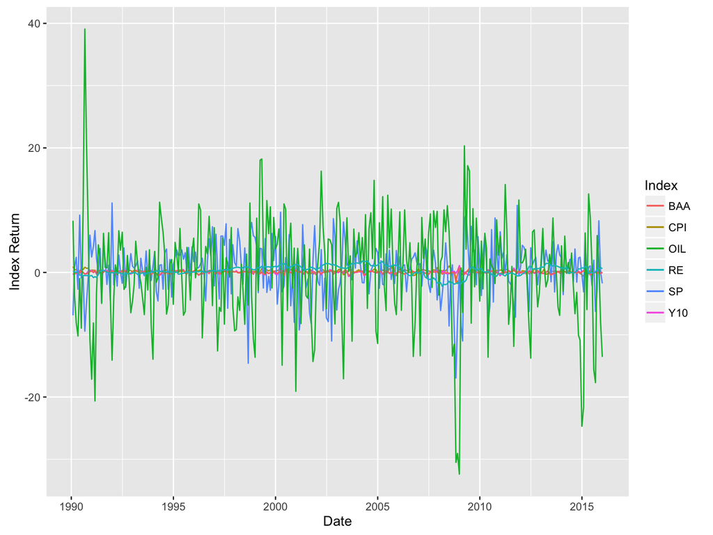

```r
df = data.frame(cbind(cpi_ret,sp_ret,y10_ret,baa_ret,oil_ret,case_ret))*100
names(df) = c("CPI","SP","Y10","BAA","OIL","RE")
dts = ymd(as.character.Date(sp$caldt))
df$YMD = dts

#Plot these series
library(ggplot2)
ggplot(df, aes(YMD)) +
  geom_line(aes(y = CPI, colour = "CPI")) +
  geom_line(aes(y = SP, colour = "SP")) +
  geom_line(aes(y = Y10, colour = "Y10")) +
  geom_line(aes(y = BAA, colour = "BAA")) +
  geom_line(aes(y = OIL, colour = "OIL")) +
  geom_line(aes(y = RE, colour = "RE")) +
  labs(x="Date",y="Index Return",colour="Index")
```

```r
save(df,n,file="SACM.RData")
write.csv(df,file="SACM_Pct_Monthly_ContinuousCompoundedReturns.csv",row.names=FALSE)
```

# Raw Correlation and Covariance (from monthly returns, then annualized)

```r
library(zoo)
load("SACM.RData")
```

This covariance below matches the one in Dave’s spreadsheet. See SACM_Pct_Monthly_ContinuousCompoundedReturns 1.xlsx

```r
data_freq = 12   #nobs per year

data = df[,1:6]
corRaw = cor(data)
print(round(corRaw,6))
```

```
##           CPI        SP       Y10       BAA       OIL        RE
## CPI  1.000000 -0.014920 -0.184222  0.038079  0.514104 -0.000489
## SP  -0.014920  1.000000 -0.028247  0.154405  0.017517  0.074554
## Y10 -0.184222 -0.028247  1.000000  0.656965 -0.266023 -0.095528
## BAA  0.038079  0.154405  0.656965  1.000000 -0.049359  0.063937
## OIL  0.514104  0.017517 -0.266023 -0.049359  1.000000  0.062214
## RE  -0.000489  0.074554 -0.095528  0.063937  0.062214  1.000000
```

We create the annualized covariance matrix from the raw data.

```r
cvRaw = cov(data)*data_freq
print(round(cvRaw,6))
```

```
##           CPI         SP       Y10       BAA        OIL        RE
## CPI  0.864770  -0.202084 -0.133172  0.024708  14.076987 -0.001237
## SP  -0.202084 212.139082 -0.319817  1.569218   7.512259  2.951948
## Y10 -0.133172  -0.319817  0.604286  0.356348  -6.089041 -0.201876
## BAA  0.024708   1.569218  0.356348  0.486879  -1.014117  0.121280
## OIL 14.076987   7.512259 -6.089041 -1.014117 866.996244  4.979995
## RE  -0.001237   2.951948 -0.201876  0.121280   4.979995  7.390254
```

# Correllogram for Raw Data

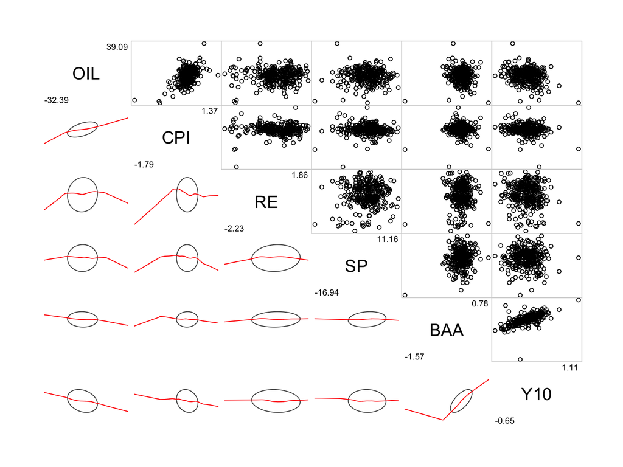

```r
library(corrgram)
corrgram(data, order=TRUE, lower.panel=panel.ellipse,
  upper.panel=panel.pts, text.panel=panel.txt,
  diag.panel=panel.minmax)
```

# Procedure to Generate SACM

- We see that the procedure is easy to code up and implement.
- Also note that it generates non-positive-definite adjusted covariance matrices that need to be corrected, as done with the function **nearPD** below.

```r
library(mvtnorm)
library(Matrix)
library(matrixcalc)

#Create overlapping one year returns
data2 = as.data.frame(rollapply(data,12,sum))

sample_size = 1000
sample_length = 60
nobs = dim(data2)[1]
```

**MAIN IDEA OF THE PAPER**

Create a covariance matrix from overlapping annual samples. Also create a “complimentary” covariance matrix from non-overlapping monthly data that was from the rest of the sample, i.e., inject small-sample, independence, and interval error. The difference between these two covariance matrices forms the basis for correcting an original covariane matrix.

```r
#Create all covariance matrices across overlapping samples (annualized covariance)
Sig = list(); SigC = list()  #latter is the cov matrix from complement setof data
SigBase = cvRaw; SigErr = list(); SigCorrected = list()
SACM_sample = NULL
ss = sample_length - 1

#Get SigErr matrices for each subsample
for (j in 1:(nobs-ss)) {
  #Generate subsample covariance matrix
  i = seq(j,j+ss)
  Sig[[j]] = cov(data2[i,1:6])
  #Generate complement sample covariance matrix
  ic = setdiff(seq(1,nobs),i)
  SigC[[j]] = cov(df[ic,1:6])*data_freq
  #Generate Error matrices
  SigErr[[j]] = Sig[[j]] - SigC[[j]]
}
```

Calculate the correction median and normalize the correction.

```r
#Calculate Median SigErr matrix (needed for correction in next code chunk)
x = matrix(unlist(SigErr),ncol=36,byrow=TRUE)
xmed = rep(0,36)
for (j in 1:36) {
  xmed[j] = median(x[,j])
}
SigErrMedian = matrix(xmed,6,6)


#Correct SigErr matrices and get corrected Covariance matrices
for (j in 1:(nobs-ss)) {
  #Center SigErr by subtracting the median (see footnote 7 in paper)
  SigErr[[j]] = SigErr[[j]] - SigErrMedian
  #Add each error matrix to the baseline matrix
  SigCorrected[[j]] = as.matrix(SigBase + SigErr[[j]])
  #Check if this matrix is positive definite, else fix it
  SigCorrected[[j]] = as.matrix(nearPD(SigCorrected[[j]])$mat)
  #Draw 1000 samples from each Corrected Cov matrix and create dataset
  samp = rmvnorm(sample_size, mean=rep(0,6), sigma=SigCorrected[[j]])
  SACM_sample = rbind(SACM_sample,samp)
}
SACM_sample = as.data.frame(SACM_sample)
names(SACM_sample) = names(data2)
```

# Compare the SACM data with the Raw Correlations and Covariances

```r
corSACM = cor(SACM_sample)
print(round(corSACM,6))
```

```
##           CPI       SP       Y10      BAA       OIL        RE
## CPI  1.000000 0.159255 -0.102223 0.080491  0.648900  0.005435
## SP   0.159255 1.000000  0.007874 0.344892  0.281110  0.459130
## Y10 -0.102223 0.007874  1.000000 0.348981 -0.196204 -0.177386
## BAA  0.080491 0.344892  0.348981 1.000000  0.060538  0.293048
## OIL  0.648900 0.281110 -0.196204 0.060538  1.000000  0.133284
## RE   0.005435 0.459130 -0.177386 0.293048  0.133284  1.000000
```

```r
print(round(corRaw,6))
```

```
##           CPI        SP       Y10       BAA       OIL        RE
## CPI  1.000000 -0.014920 -0.184222  0.038079  0.514104 -0.000489
## SP  -0.014920  1.000000 -0.028247  0.154405  0.017517  0.074554
## Y10 -0.184222 -0.028247  1.000000  0.656965 -0.266023 -0.095528
## BAA  0.038079  0.154405  0.656965  1.000000 -0.049359  0.063937
## OIL  0.514104  0.017517 -0.266023 -0.049359  1.000000  0.062214
## RE  -0.000489  0.074554 -0.095528  0.063937  0.062214  1.000000
```

```r
#idx = sample(seq(1,dim(SACM_sample)[1]),n)
#corrgram(SACM_sample[idx,], order=TRUE, lower.panel=panel.ellipse,
#  upper.panel=panel.pts, text.panel=panel.txt,
#  diag.panel=panel.minmax)
print(round(cvRaw,6))
```

```
##           CPI         SP       Y10       BAA        OIL        RE
## CPI  0.864770  -0.202084 -0.133172  0.024708  14.076987 -0.001237
## SP  -0.202084 212.139082 -0.319817  1.569218   7.512259  2.951948
## Y10 -0.133172  -0.319817  0.604286  0.356348  -6.089041 -0.201876
## BAA  0.024708   1.569218  0.356348  0.486879  -1.014117  0.121280
## OIL 14.076987   7.512259 -6.089041 -1.014117 866.996244  4.979995
## RE  -0.001237   2.951948 -0.201876  0.121280   4.979995  7.390254
```

```r
cvSACM = cov(SACM_sample)
print(round(cvSACM,6))
```

```
##           CPI         SP       Y10      BAA        OIL        RE
## CPI  1.535510   2.902312 -0.160110 0.086137  24.593497  0.044220
## SP   2.902312 216.295322  0.146365 4.380479 126.449313 44.333014
## Y10 -0.160110   0.146365  1.597684 0.380945  -7.585231 -1.472089
## BAA  0.086137   4.380479  0.380945 0.745813   1.599041  1.661583
## OIL 24.593497 126.449313 -7.585231 1.599041 935.474240 26.764676
## RE   0.044220  44.333014 -1.472089 1.661583  26.764676 43.105901
```

# Generate data from raw sample for comparison

```r
#Generate data from rawCV assuming normality from annualized cov matrix
rawSamp = rmvnorm(dim(SACM_sample)[1],mean=rep(0,6),sigma=cvRaw)
print(dim(rawSamp))
```

```
## [1] 242000      6
```

```r
rawSamp = as.data.frame(rawSamp)
names(rawSamp) = names(data2)
```

In the next 6 panels we compare the data generated from the SACM approach with raw data from the sample. We see that while the SACM series are symmetric in distribution they are much fatter-tailed than the raw data would present, assuming normality. This confirms the results in the paper.

# Histogram of CPI (raw and SACM)

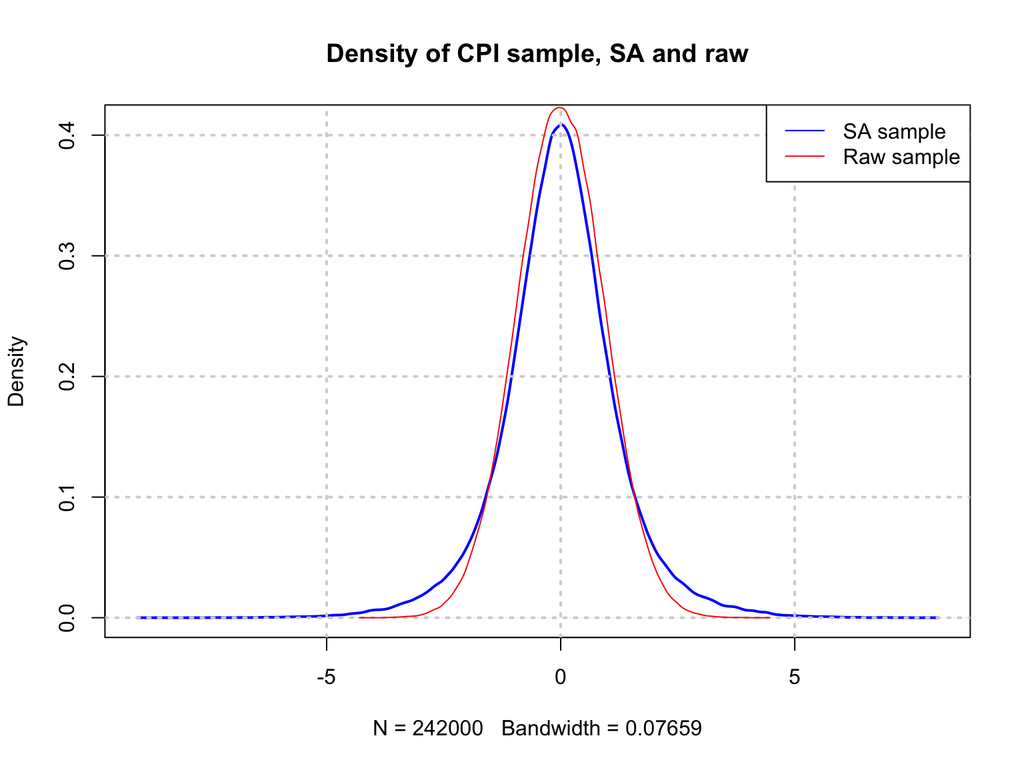

```r
dat <- as.data.frame(cbind(rawSamp$CPI,SACM_sample$CPI))
plot(density(dat$V2),col="blue",main="Density of CPI sample, SA and raw",lwd=2); grid(lwd=2)
legend("topright",c("SA sample","Raw sample"),lty=c(1,1),col=c("blue","red"))
lines(density(dat$V1),col="red")
```

# Histogram of SP (raw and SACM)

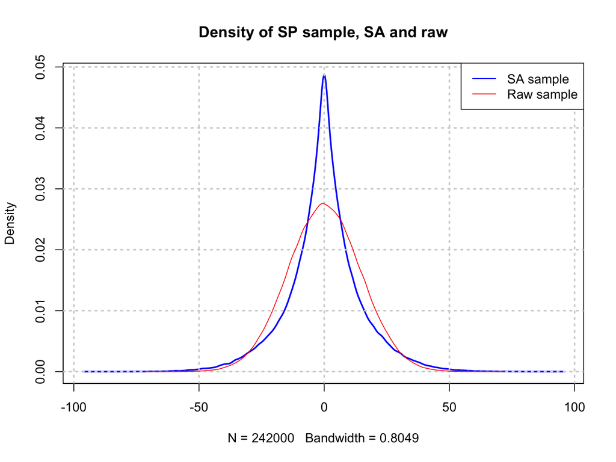

```r
dat <- as.data.frame(cbind(rawSamp$SP,SACM_sample$SP))
plot(density(dat$V2),col="blue",main="Density of SP sample, SA and raw",lwd=2); grid(lwd=2)
legend("topright",c("SA sample","Raw sample"),lty=c(1,1),col=c("blue","red"))
lines(density(dat$V1),col="red")
```

# Histogram of Y10 (raw and SACM)

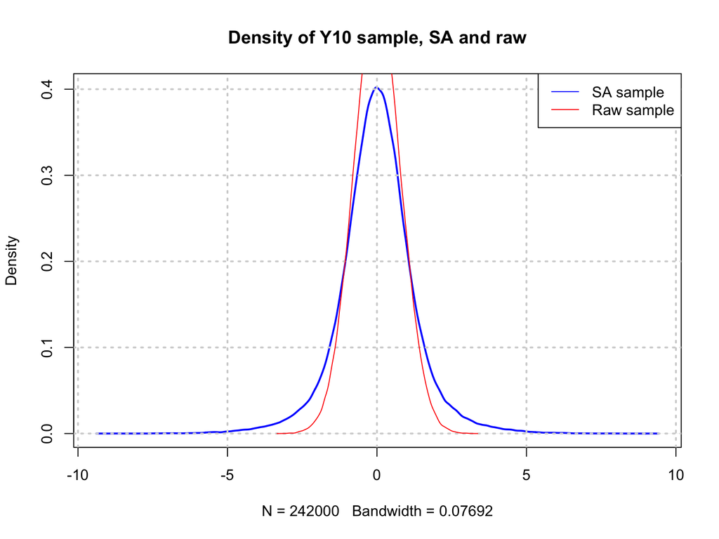

```r
dat <- as.data.frame(cbind(rawSamp$Y10,SACM_sample$Y10))
plot(density(dat$V2),col="blue",main="Density of Y10 sample, SA and raw",lwd=2); grid(lwd=2)
legend("topright",c("SA sample","Raw sample"),lty=c(1,1),col=c("blue","red"))
lines(density(dat$V1),col="red")
```

# Histogram of BAA (raw and SACM)

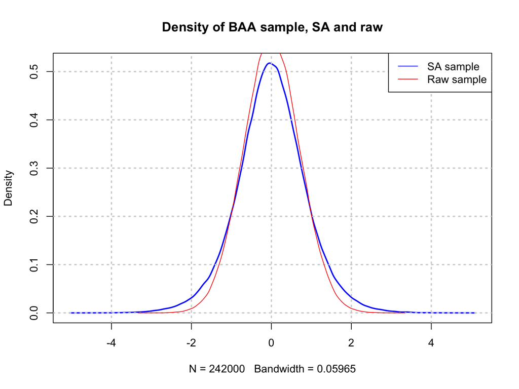

```r
dat <- as.data.frame(cbind(rawSamp$BAA,SACM_sample$BAA))
plot(density(dat$V2),col="blue",main="Density of BAA sample, SA and raw",lwd=2); grid(lwd=2)
legend("topright",c("SA sample","Raw sample"),lty=c(1,1),col=c("blue","red"))
lines(density(dat$V1),col="red")
```

# Histogram of OIL (raw and SACM)

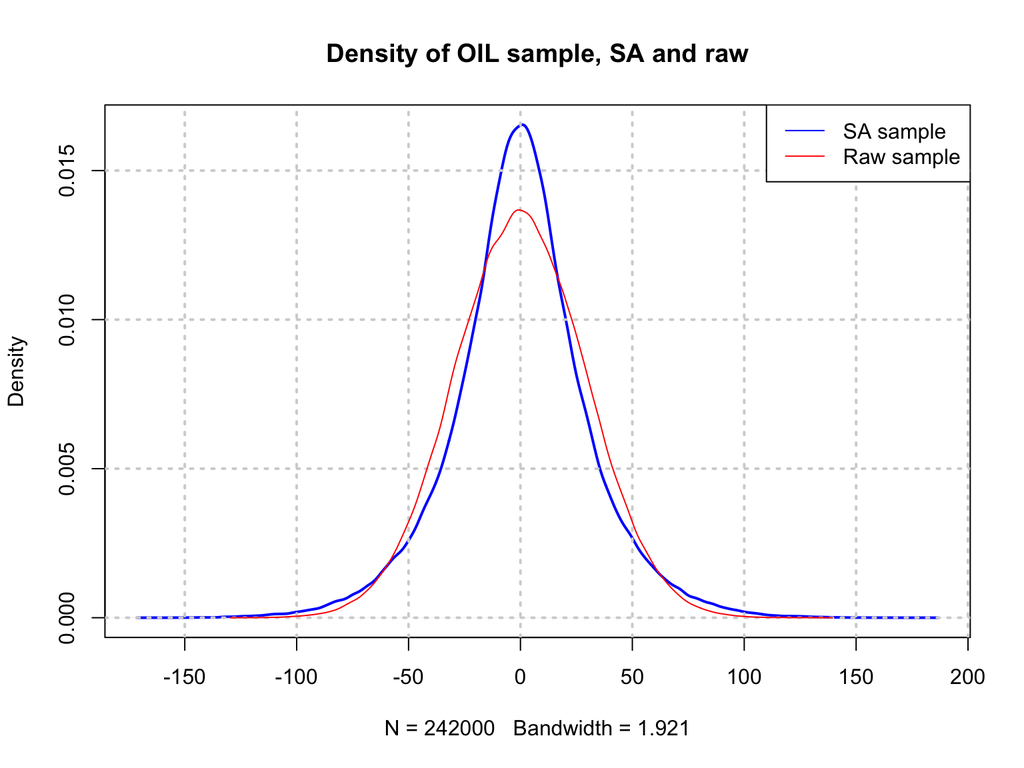

```r
dat <- as.data.frame(cbind(rawSamp$OIL,SACM_sample$OIL))
plot(density(dat$V2),col="blue",main="Density of OIL sample, SA and raw",lwd=2); grid(lwd=2)
legend("topright",c("SA sample","Raw sample"),lty=c(1,1),col=c("blue","red"))
lines(density(dat$V1),col="red")
```

# Histogram of RE (raw and SACM)

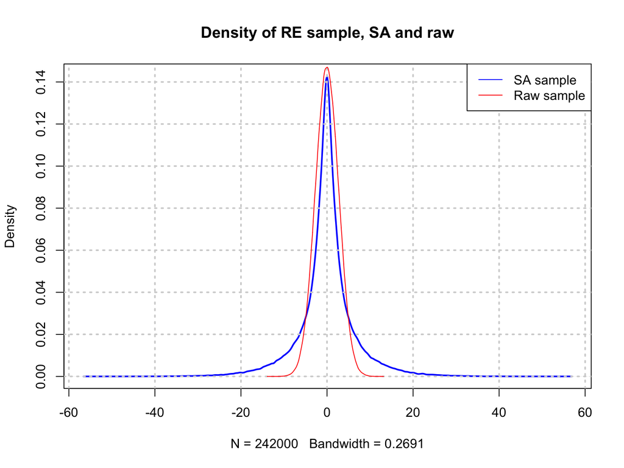

```r
dat <- as.data.frame(cbind(rawSamp$RE,SACM_sample$RE))
plot(density(dat$V2),col="blue",main="Density of RE sample, SA and raw",lwd=2); grid(lwd=2)
legend("topright",c("SA sample","Raw sample"),lty=c(1,1),col=c("blue","red"))
lines(density(dat$V1),col="red")
```

# Get Weights (Unconstrained) for all three models

The three models are:

- Raw Gaussian Model
- Stability Adjusted Model (SACM)
- Empirical

As suggested by the authors, we can find the replication weights using a regression of the target index on the replicating securities, as follows:

```r
#Raw Covariance Matrix
res = lm(CPI ~ SP+Y10+BAA+OIL+RE-1, data=rawSamp)
print(summary(res))
```

```
##
## Call:
## lm(formula = CPI ~ SP + Y10 + BAA + OIL + RE - 1, data = rawSamp)
##
## Residuals:
##     Min      1Q  Median      3Q     Max
## -3.3052 -0.5267  0.0023  0.5294  3.6652
##
## Coefficients:
##       Estimate Std. Error t value Pr(>|t|)
## SP  -3.659e-03  1.126e-04  -32.50   <2e-16 ***
## Y10 -2.376e-01  2.942e-03  -80.76   <2e-16 ***
## BAA  2.760e-01  3.200e-03   86.27   <2e-16 ***
## OIL  1.499e-02  5.706e-05  262.77   <2e-16 ***
## RE  -2.009e-02  5.989e-04  -33.55   <2e-16 ***
## ---
## Signif. codes:  0 '***' 0.001 '**' 0.01 '*' 0.05 '.' 0.1 ' ' 1
##
## Residual standard error: 0.7841 on 241995 degrees of freedom
## Multiple R-squared:  0.2885, Adjusted R-squared:  0.2885
## F-statistic: 1.962e+04 on 5 and 241995 DF,  p-value: < 2.2e-16
```

```r
wtsRaw = matrix(c(-1,res$coefficients))

#SACM
res = lm(CPI ~ SP+Y10+BAA+OIL+RE-1, data=SACM_sample)
print(summary(res))
```

```
##
## Call:
## lm(formula = CPI ~ SP + Y10 + BAA + OIL + RE - 1, data = SACM_sample)
##
## Residuals:
##     Min      1Q  Median      3Q     Max
## -8.4848 -0.5716  0.0008  0.5704  5.7054
##
## Coefficients:
##       Estimate Std. Error t value Pr(>|t|)
## SP  -0.0002608  0.0001551  -1.682   0.0926 .
## Y10 -0.0205949  0.0017252 -11.937   <2e-16 ***
## BAA  0.1159991  0.0026114  44.420   <2e-16 ***
## OIL  0.0265424  0.0000662 400.923   <2e-16 ***
## RE  -0.0203609  0.0003445 -59.094   <2e-16 ***
## ---
## Signif. codes:  0 '***' 0.001 '**' 0.01 '*' 0.05 '.' 0.1 ' ' 1
##
## Residual standard error: 0.9333 on 241995 degrees of freedom
## Multiple R-squared:  0.4327, Adjusted R-squared:  0.4327
## F-statistic: 3.691e+04 on 5 and 241995 DF,  p-value: < 2.2e-16
```

```r
wtsSACM = matrix(c(-1,res$coefficients))

#Empirical
res = lm(CPI ~ SP+Y10+BAA+OIL+RE-1, data=data)
print(summary(res))
```

```
##
## Call:
## lm(formula = CPI ~ SP + Y10 + BAA + OIL + RE - 1, data = data)
##
## Residuals:
##      Min       1Q   Median       3Q      Max
## -1.11453  0.05404  0.18195  0.31071  1.28702
##
## Coefficients:
##      Estimate Std. Error t value Pr(>|t|)
## SP   0.002793   0.004121   0.678  0.49847
## Y10 -0.076524   0.107835  -0.710  0.47847
## BAA  0.176656   0.117858   1.499  0.13493
## OIL  0.015960   0.002105   7.581 4.09e-13 ***
## RE   0.065025   0.020792   3.127  0.00193 **
## ---
## Signif. codes:  0 '***' 0.001 '**' 0.01 '*' 0.05 '.' 0.1 ' ' 1
##
## Residual standard error: 0.2997 on 307 degrees of freedom
## Multiple R-squared:  0.2185, Adjusted R-squared:  0.2058
## F-statistic: 17.17 on 5 and 307 DF,  p-value: 5.58e-15
```

```r
wtsEmpirical = matrix(c(-1,res$coefficients))

print(cbind(wtsRaw,wtsSACM,wtsEmpirical))
```

```
##              [,1]         [,2]         [,3]
## [1,] -1.000000000 -1.000000000 -1.000000000
## [2,] -0.003659206 -0.000260805  0.002792871
## [3,] -0.237617289 -0.020594898 -0.076523520
## [4,]  0.276042619  0.115999059  0.176656334
## [5,]  0.014993411  0.026542393  0.015959525
## [6,] -0.020092557 -0.020360930  0.065024601
```

Weights are in the same ballpark but do lead to very different tracking error.

# Three tracking errors (**unconstrained** case), but with overlapping annual returns

When tracking errors are high, the SACM tends to do better!!

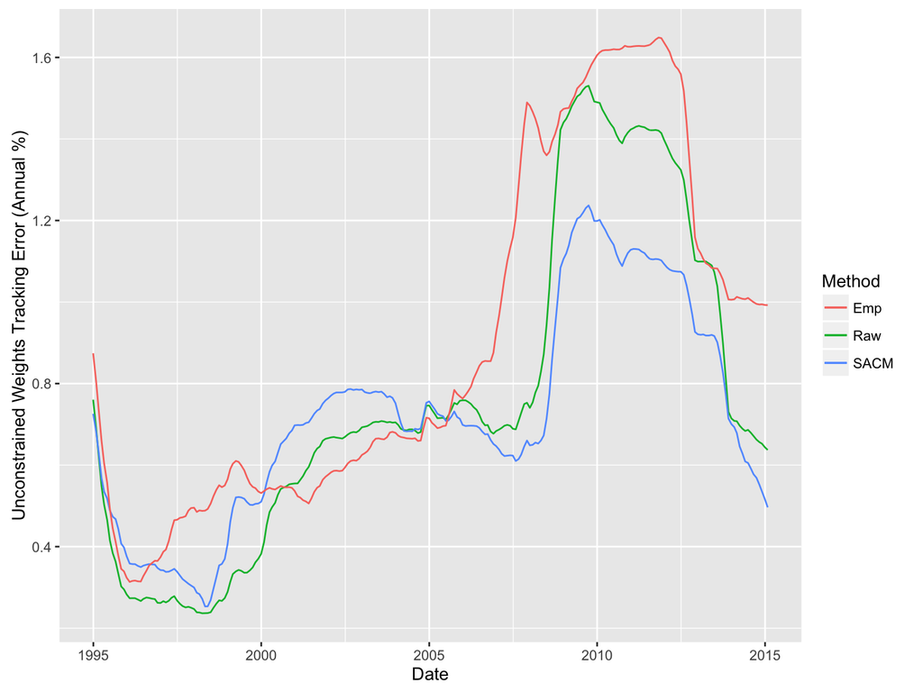

```r
returnsAnnual = as.matrix(data2)
retRaw = returnsAnnual %*% wtsRaw
retSACM = returnsAnnual %*% wtsSACM
retEmpirical = returnsAnnual %*% wtsEmpirical

teRaw_a = rollapply(retRaw,60,sd)
teSACM_a = rollapply(retSACM,60,sd)
teEmpirical_a = rollapply(retEmpirical,60,sd)

dat = data.frame(df$YMD[60:dim(retRaw)[1]],teRaw_a,teSACM_a,teEmpirical_a)
names(dat) = c("YMD","teRaw","teSACM","teEmpirical")
ggplot(dat, aes(YMD)) +
  geom_line(aes(y = teRaw_a, colour = "Raw")) +
  geom_line(aes(y = teSACM_a, colour = "SACM")) +
  geom_line(aes(y = teEmpirical_a, colour = "Emp")) +
  labs(x="Date",y="Unconstrained Weights Tracking Error (Annual %)",colour="Method")
```

# Mean-Variance Tracking Error Problem

Let $w$ be a vector of weights, $\Sigma$ is the covariance matrix.

$$\min_w \frac{1}{2} w^\top \Sigma w$$
subject to

- Force the first asset’s weights to $-1$:

$$w^\top k = -1, \quad k = [1,0,0,0,0,0]^\top$$

- The sum of the weights must be zero across as all assets:

$$w^\top i = 0, \quad i = [1,1,1,1,1,1]^\top$$

By minimizing the variance of portfolio returns, in a setting where the target asset has forced weight of $-1$, and the other tracking portflio assets weights are $+1$ in total, we get aggregate net zero weight for all assets in a combined portfolio, and also mimic a tracking error problem.

Next, we solve this in closed-form.

# Closed-form solution

Set up the lagrangain problem:

$$\min_w L = \frac{1}{2} w^\top \Sigma w - \lambda_1 w^\top i + \lambda_2 (-1 - w^\top k)$$

First-order conditions:

$$\frac{\partial L}{\partial w} = \Sigma w - \lambda_1 i - \lambda_2 k$$

which implies

$$w = \lambda_1 \Sigma^{-1} i + \lambda_2 \Sigma^{-1} k$$

# Solve for $\lambda_1$, $\lambda_2$

Use the constraints as follows:

$$\begin{eqnarray}
i^\top w = 0 &=& \lambda_1 i^\top \Sigma^{-1} i + \lambda_2 i^\top \Sigma^{-1} k \\
k^\top w = -1 &=& \lambda_1 k^\top \Sigma^{-1} i + \lambda_2 k^\top \Sigma^{-1} k
\end{eqnarray}$$

Rewrite this by setting $A = i^\top \Sigma^{-1} i$, $B=\lambda_2 i^\top \Sigma^{-1} k$, $C = k^\top \Sigma^{-1} k$.

$$\begin{eqnarray}
i^\top w = 0 &=& \lambda_1 A + \lambda_2 B \\
k^\top w = -1 &=& \lambda_1 B + \lambda_2 C
\end{eqnarray}$$

The solution is, given $D = B^2 - AC$:

$$\begin{eqnarray}
\lambda_1 &=& \frac{-B}{D} \\
\lambda_2 &=& \frac{A}{D}
\end{eqnarray}$$

$$w = -\frac{B}{D} \Sigma^{-1} i + \frac{A}{D} \Sigma^{-1} k$$

# Function for the solution, using the covariance matrix

```r
#Minimize tracking error
minTE = function(cv) {
  m = length(diag(cv))  #no of assets
  i = matrix(1,m,1)
  k = matrix(c(1,0,0,0,0,0),m,1)
  A = t(i) %*% solve(cv) %*% i
  B = t(i) %*% solve(cv) %*% k
  C = t(k) %*% solve(cv) %*% k
  D = B^2 - A*C
  lam1 = -B/D
  lam2 = A/D
  w = lam1[1]*(solve(cv)%*%i) + lam2[1]*(solve(cv)%*%k)
}
```

# Solution

We see that the solution is not that different for the raw covariance matrix and the SACM. Since no weights were provided in the paper, one cannot comment on whether this was expected.

#### Raw CV case

```r
wtsRaw = minTE(cvRaw)
print(wtsRaw)
```

```
##             [,1]
## CPI -1.000000000
## SP  -0.005844912
## Y10  0.161105841
## BAA  0.791740753
## OIL  0.018601946
## RE   0.034396371
```

```r
#print(t(wtsRaw) %*% i)
#print(t(wtsRaw) %*% k)
```

#### SACM case

```r
wtsSACM = minTE(cvSACM)
print(wtsSACM)
```

```
##            [,1]
## CPI -1.00000000
## SP  -0.01497500
## Y10  0.17622740
## BAA  0.82412715
## OIL  0.02934620
## RE  -0.01472576
```

```r
#print(t(wtsSACM) %*% i)
#print(t(wtsSACM) %*% k)
```

# Tracking errors (**constrained** case), with overlapping annual returns

When tracking errors are high, the SACM tends to do better!

```r
returnsAnnual = as.matrix(data2)
retRaw = returnsAnnual %*% wtsRaw
retSACM = returnsAnnual %*% wtsSACM

teRaw_a = rollapply(retRaw,60,sd)
teSACM_a = rollapply(retSACM,60,sd)

print(mean(teRaw_a))
```

```
## [1] 1.051165
```

```r
print(mean(teSACM_a))
```

```
## [1] 0.9610145
```

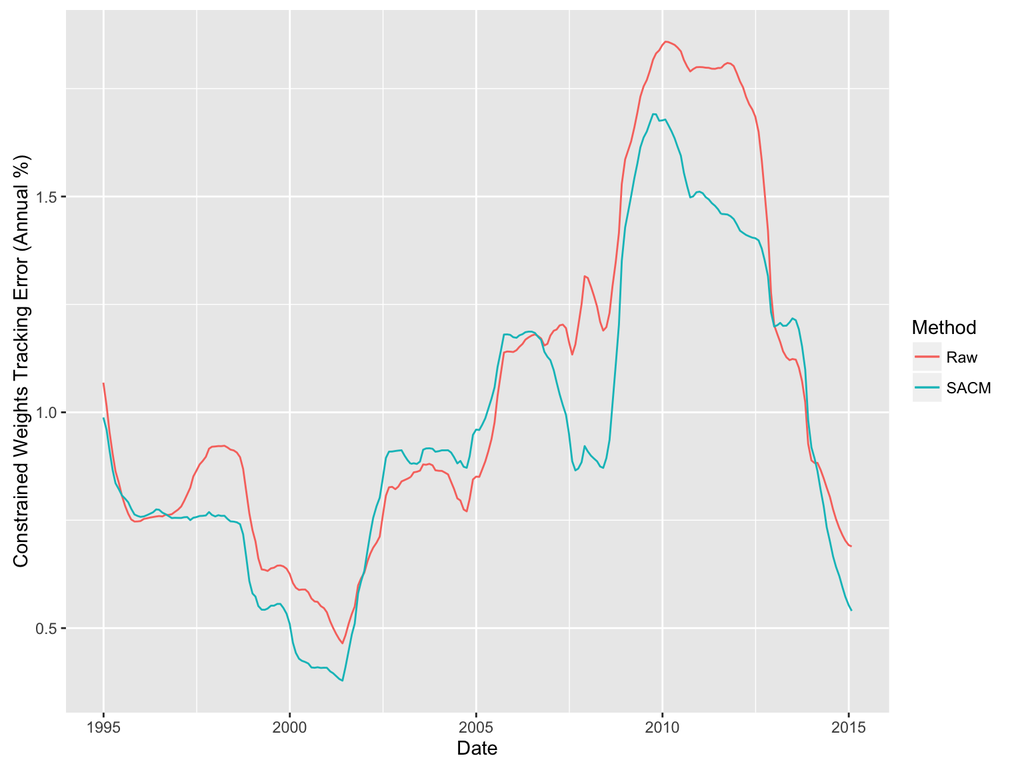

```r
dat = data.frame(df$YMD[60:dim(retRaw)[1]],teRaw_a,teSACM_a)
names(dat) = c("YMD","teRaw","teSACM")
ggplot(dat, aes(YMD)) +
  geom_line(aes(y = teRaw_a, colour = "Raw")) +
  geom_line(aes(y = teSACM_a, colour = "SACM")) +
  labs(x="Date",y="Constrained Weights Tracking Error (Annual %)",colour="Method")
```

# Decomposition of the Tracking Error with just one replicating asset

First, let’s take the case with only one replicating asset, i.e., OIL. We create a function to do the entire analysis at one go, by passing the relevant data set.

```r
TE_Analysis = function(df,data_freq=12,sample_size=1000,sample_length=60,
                       show_plot=TRUE,
                       overlap_returns=TRUE) {
  m = dim(df)[2]-1    #assets, first one is target

  #Create overlapping one year returns
  data = df[,1:m]
  cvRaw = cov(data)*data_freq
  print(round(cor(data),6))
  data2 = as.data.frame(rollapply(data,data_freq,sum))
  nobs = dim(data2)[1]

  #Create all covariance matrices across overlapping samples (annualized covariance)
  Sig = list(); SigC = list()  #latter is the cov matrix from complement setof data
  SigBase = cvRaw; SigErr = list(); SigCorrected = list()
  SACM_sample = NULL
  ss = sample_length - 1

  #Get SigErr matrices for each subsample
  for (j in 1:(nobs-ss)) {
    #Generate subsample covariance matrix
    i = seq(j,j+ss)
    Sig[[j]] = cov(data2[i,1:m])
    #Generate complement sample covariance matrix
    ic = setdiff(seq(1,nobs),i)
    SigC[[j]] = cov(df[ic,1:m])*data_freq
    #Generate Error matrices
    SigErr[[j]] = Sig[[j]] - SigC[[j]]
  }

  #Calculate Median SigErr matrix (needed for correction in next code chunk)
  x = matrix(unlist(SigErr),ncol=m^2,byrow=TRUE)
  xmed = rep(0,m^2)
  for (j in 1:m^2) {
    xmed[j] = median(x[,j])
  }
  SigErrMedian = matrix(xmed,m,m)

  #Correct SigErr matrices and get corrected Covariance matrices
  for (j in 1:(nobs-ss)) {
    #Center SigErr by subtracting the median (see footnote 7 in paper)
    SigErr[[j]] = SigErr[[j]] - SigErrMedian
    #Add each error matrix to the baseline matrix
    SigCorrected[[j]] = as.matrix(SigBase + SigErr[[j]])
    #Check if this matrix is positive definite, else fix it
    SigCorrected[[j]] = as.matrix(nearPD(SigCorrected[[j]])$mat)
    #Draw 1000 samples from each Corrected Cov matrix and create dataset
    samp = rmvnorm(sample_size, mean=rep(0,m), sigma=SigCorrected[[j]])
    SACM_sample = rbind(SACM_sample,samp)
  }
  SACM_sample = as.data.frame(SACM_sample)
  names(SACM_sample) = names(data)

  #Generate data from rawCV assuming normality from annualized cov matrix
  rawSamp = rmvnorm(dim(SACM_sample)[1],mean=rep(0,m),sigma=cvRaw)
  print(dim(rawSamp))
  rawSamp = as.data.frame(rawSamp)
  names(rawSamp) = names(data)

  #Regressions to get tracking asset weights
  #Raw Covariance Matrix
  res = lm(CPI ~ OIL-1, data=rawSamp)
  wtsRaw = matrix(c(-1,res$coefficients))
  #SACM
  res = lm(CPI ~ OIL-1, data=SACM_sample)
  wtsSACM = matrix(c(-1,res$coefficients))
  #Empirical
  res = lm(CPI ~ OIL-1, data=data)
  wtsEmpirical = matrix(c(-1,res$coefficients))

  ## Calculate and plot tracking error (annual overlapping returns)
  print("Wts: Raw, SACM, Empirical = "); print(cbind(wtsRaw,wtsSACM,wtsEmpirical))

  if (overlap_returns==TRUE) {
    returns = as.matrix(data2)
    retRaw = returns %*% wtsRaw
    retSACM = returns %*% wtsSACM
    retEmpirical = returns %*% wtsEmpirical
    teRaw_a = rollapply(retRaw,sample_length,sd)
    teSACM_a = rollapply(retSACM,sample_length,sd)
    teEmpirical_a = rollapply(retEmpirical,sample_length,sd)
  }
  else {
    returns = as.matrix(data2[seq(data_freq,nobs,data_freq),])
    retRaw = returns %*% wtsRaw
    retSACM = returns %*% wtsSACM
    retEmpirical = returns %*% wtsEmpirical
    teRaw_a = rollapply(retRaw,sample_length/data_freq,sd)
    teSACM_a = rollapply(retSACM,sample_length/data_freq,sd)
    teEmpirical_a = rollapply(retEmpirical,sample_length/data_freq,sd)
  }

  print("Avg SD of Tracking Error")
  print(c(mean(teRaw_a),mean(teSACM_a),mean(teEmpirical_a)))

  if (show_plot) {
    if (overlap_returns==TRUE) {
      dat = data.frame(df$YMD[sample_length:dim(retRaw)[1]],
                       teRaw_a,teSACM_a,teEmpirical_a) }
    else {
      nn = length(teRaw_a); idx = seq(1,nobs,ceiling(nobs/nn))
      dat = data.frame(df$YMD[idx[1:nn]],teRaw_a,teSACM_a,teEmpirical_a)
    }
    names(dat) = c("YMD","teRaw","teSACM","teEmpirical")
    ggplot(dat, aes(YMD)) +
      geom_line(aes(y = teRaw_a, colour = "Raw")) +
      geom_line(aes(y = teSACM_a, colour = "SACM")) +
      geom_line(aes(y = teEmpirical_a, colour = "Emp")) +
      labs(x="Date",y="Unconstrained Weights Tracking Error (Annual %)",colour="Method")
  }
}
```

# Call the function for the base case

```r
#Create smaller data frame for two assets
df2 = df[c("CPI","OIL","YMD")]
TE_Analysis(df2)
```

```
##          CPI      OIL
## CPI 1.000000 0.514104
## OIL 0.514104 1.000000
## [1] 242000      2
## [1] "Wts: Raw, SACM, Empirical = "
##             [,1]        [,2]        [,3]
## [1,] -1.00000000 -1.00000000 -1.00000000
## [2,]  0.01632304  0.02629445  0.01674118
## [1] "Avg SD of Tracking Error"
## [1] 0.7221830 0.7263514 0.7200766
```

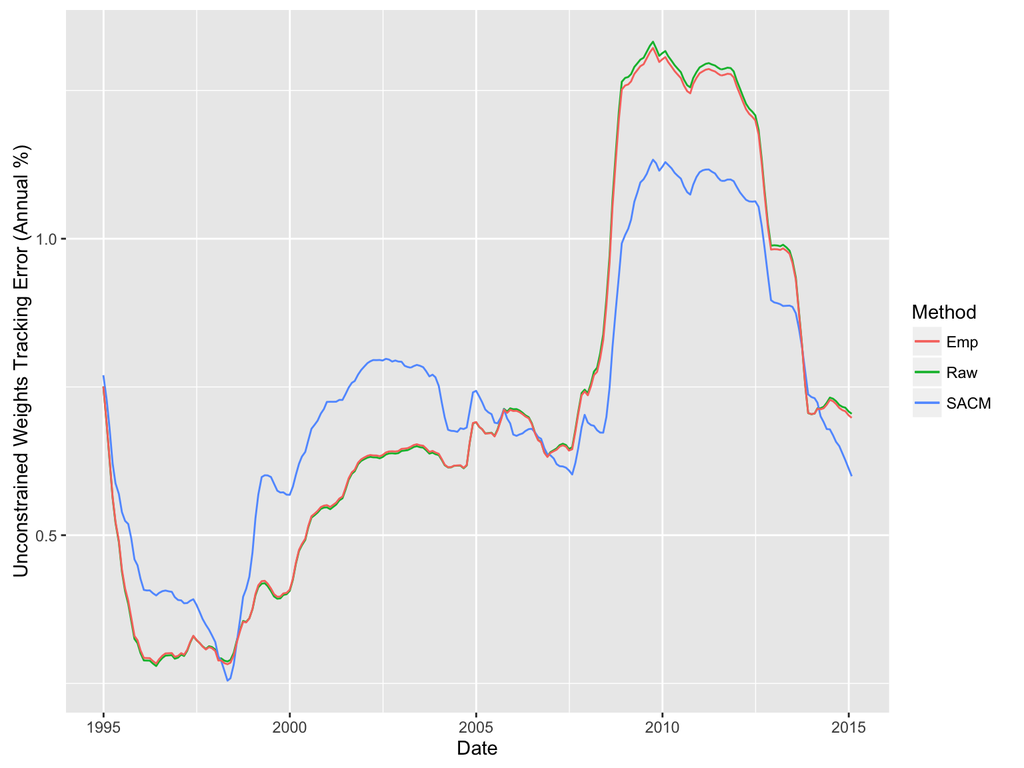

So, does SACM do better in periods of higher volatility, and worse in periods of lower volatility?

# Sub-sample Test (first half)

- It does not do so well when the correlation is low.

```r
df2 = df[c("CPI","OIL","YMD")]
df2 = df2[1:156,]
TE_Analysis(df2)
```

```
##          CPI      OIL
## CPI 1.000000 0.384694
## OIL 0.384694 1.000000
## [1] 86000     2
## [1] "Wts: Raw, SACM, Empirical = "
##              [,1]         [,2]         [,3]
## [1,] -1.000000000 -1.000000000 -1.000000000
## [2,]  0.008286735  0.007009851  0.009103698
## [1] "Avg SD of Tracking Error"
## [1] 0.4351348 0.4469245 0.4287405
```

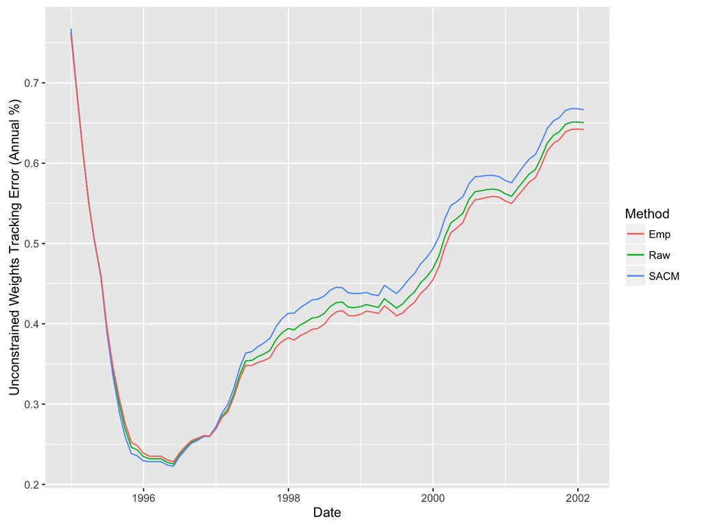

# Sub-sample Test (second half)

- It does better when the correlation is high.
- Broken into two subsamples, the regime effect is lower, so the improvement from SACM is also lower.
- **Insight**: SACM is designed to work well when there are correlation differences across regimes, when the analysis is in-sample.

```r
df2 = df[c("CPI","OIL","YMD")]
df2 = df2[157:312,]
TE_Analysis(df2)
```

```
##          CPI      OIL
## CPI 1.000000 0.603634
## OIL 0.603634 1.000000
## [1] 86000     2
## [1] "Wts: Raw, SACM, Empirical = "
##             [,1]        [,2]        [,3]
## [1,] -1.00000000 -1.00000000 -1.00000000
## [2,]  0.02283842  0.02414342  0.02290675
## [1] "Avg SD of Tracking Error"
## [1] 0.9745857 0.9592617 0.9737319
```

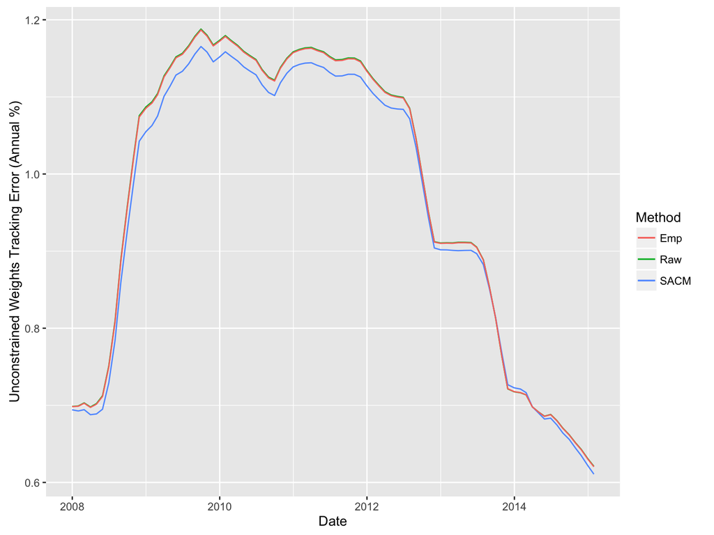

# Non-overlapping return periods (annual returns)

We use 5 consecutive non-overlapping annual returns to get the sd of tracking error.

```r
df2 = df[c("CPI","OIL","YMD")]
TE_Analysis(df2,overlap_returns = FALSE)
```

```
##          CPI      OIL
## CPI 1.000000 0.514104
## OIL 0.514104 1.000000
## [1] 242000      2
## [1] "Wts: Raw, SACM, Empirical = "
##            [,1]        [,2]        [,3]
## [1,] -1.0000000 -1.00000000 -1.00000000
## [2,]  0.0163735  0.02639429  0.01674118
## [1] "Avg SD of Tracking Error"
## [1] 0.6657948 0.7357080 0.6661120
```

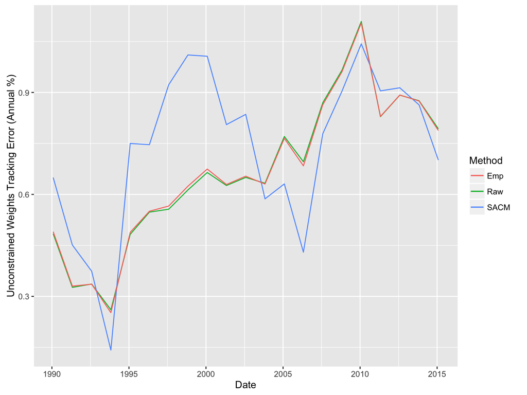

# Overlapping monthly returns

```r
df2 = df[c("CPI","OIL","YMD")]
TE_Analysis(df2,data_freq=1,overlap_returns = TRUE)
```

```
##          CPI      OIL
## CPI 1.000000 0.514104
## OIL 0.514104 1.000000
## [1] 253000      2
## [1] "Wts: Raw, SACM, Empirical = "
##             [,1]        [,2]        [,3]
## [1,] -1.00000000 -1.00000000 -1.00000000
## [2,]  0.01615686  0.02113477  0.01674118
## [1] "Avg SD of Tracking Error"
## [1] 0.2192574 0.2251225 0.2196216
```

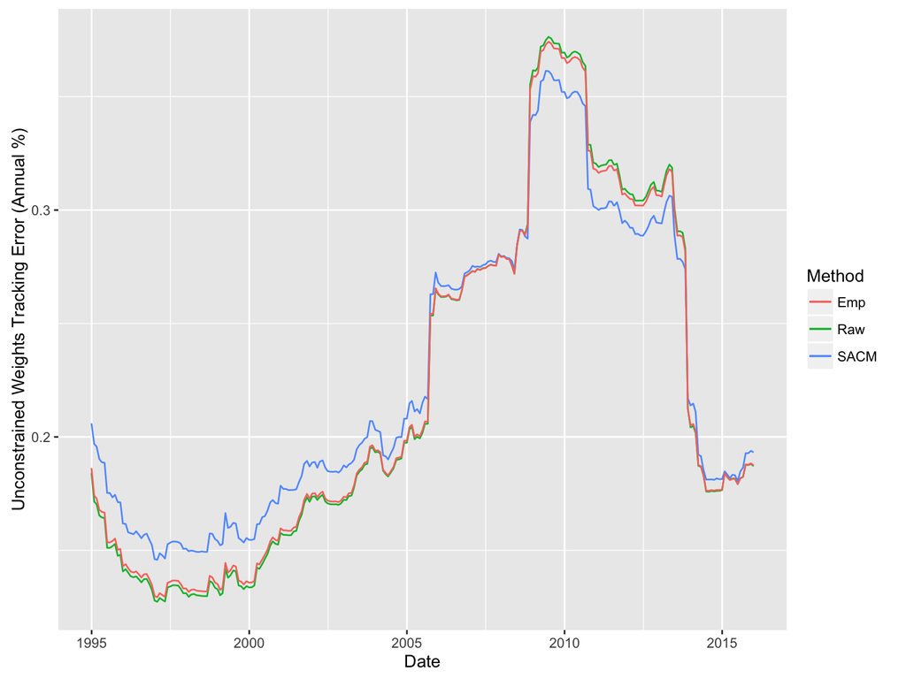

```r
#default horizon data_freq=12 (1 year)
```

# Non-overlapping monthly returns

When returns do not overlap, and there is no interval issue, the result seems to be reversed.

```r
df2 = df[c("CPI","OIL","YMD")]
TE_Analysis(df2,data_freq=1,overlap_returns = FALSE)
```

```
##          CPI      OIL
## CPI 1.000000 0.514104
## OIL 0.514104 1.000000
## [1] 253000      2
## [1] "Wts: Raw, SACM, Empirical = "
##            [,1]        [,2]        [,3]
## [1,] -1.0000000 -1.00000000 -1.00000000
## [2,]  0.0161316  0.02115444  0.01674118
## [1] "Avg SD of Tracking Error"
## [1] 0.2192437 0.2251577 0.2196216
```

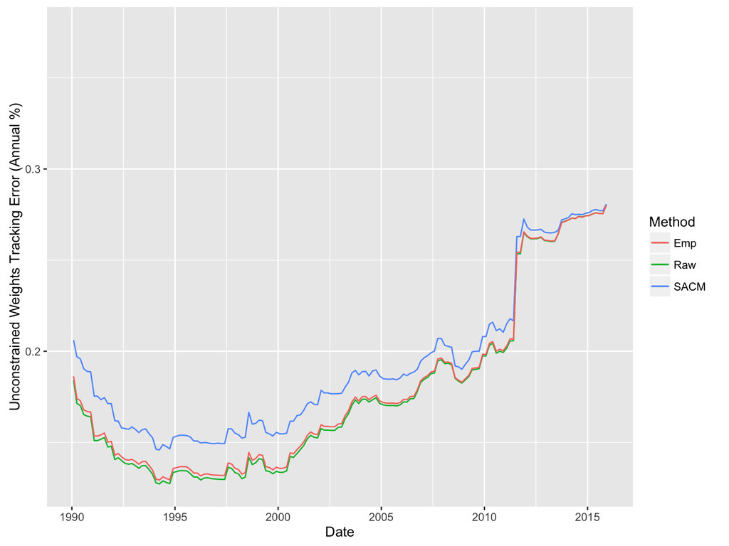

```r
#default horizon data_freq=12 (1 year)
```

# Intuition

- Work out 2x2 case: {correlation x volatility}

```r
df2 = df[c("CPI","OIL","YMD")]
print(sd(df2$CPI[1:156]))
```

```
## [1] 0.1743984
```

```r
print(sd(df2$CPI[157:312]))
```

```
## [1] 0.3351471
```

```r
print(sd(df2$OIL[1:156]))
```

```
## [1] 8.045969
```

```r
print(sd(df2$OIL[157:312]))
```

```
## [1] 8.956894
```

```r
print(cor(df2[1:156,1:2]))
```

```
##           CPI       OIL
## CPI 1.0000000 0.3846943
## OIL 0.3846943 1.0000000
```

```r
print(cor(df2[157:312,1:2]))
```

```
##           CPI       OIL
## CPI 1.0000000 0.6036344
## OIL 0.6036344 1.0000000
```

# Comments

- The tests are all done in-sample. Extend it to out-of-sample? Does it work?
- Need to explain what drives the result. I think it is a disparty of regimes that matters, but again, works in-sample.
- Need to explain when this works and when it does not. When correlation in returns is high and volatility is high, in that period it works well, and vice-versa. Better to win in the former case.
- Works when there is interval error, but in fact may not work if there is no interval error.

# Download slides here:

https://github.com/srdas/Presentations/DiscussionOf_Errors_JOIM_Oxford_Sep2016.html